# Simulation Testing Data Limited Methods **FLife**

06 December, 2018

# Introduction

This tutorial describes how to simuation test data limited methods in `FLR` using a variety of other packages.

## Required packages

To follow this tutorial you should have installed the following packages:

- FLR: [FLCore](http://www.flr-project.org/FLCore/), [FLBRP](http://www.flr-project.org/FLBRP/), [FLasher](http://www.flr-project.org/FLash/), [FLife](http://www.flr-project.org/FLife/)

for example

# Operating Model

Turbot

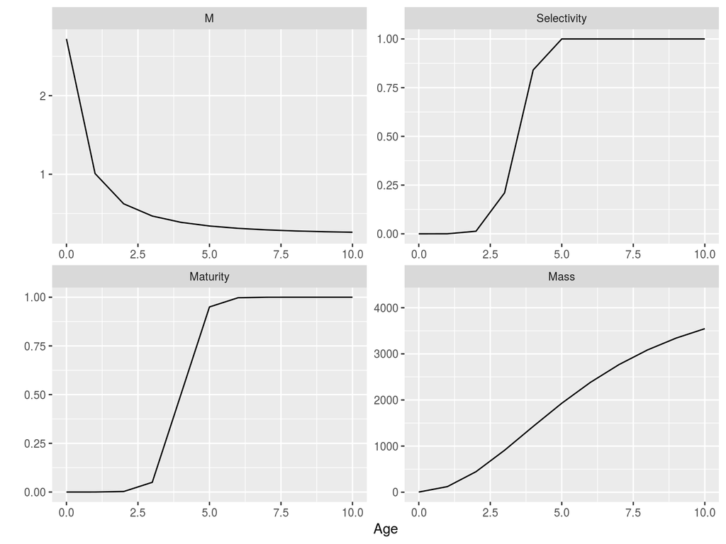

**Figure 1** Operating model for turbot.

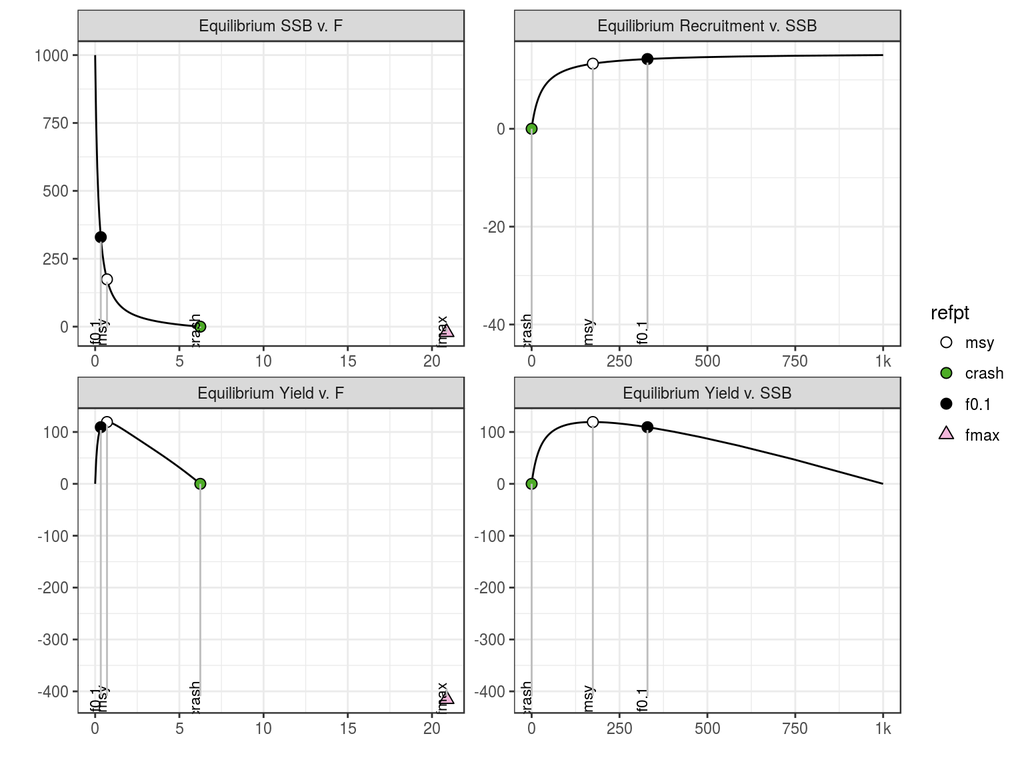

**Figure 2** Example equilibrum Curve.

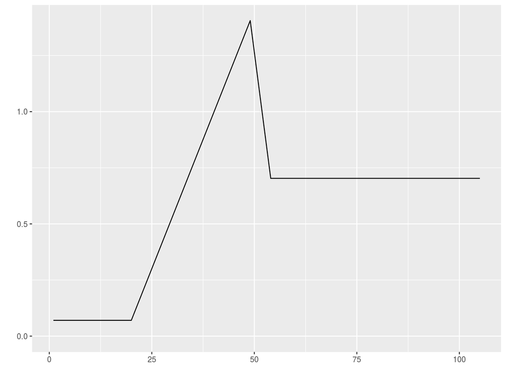

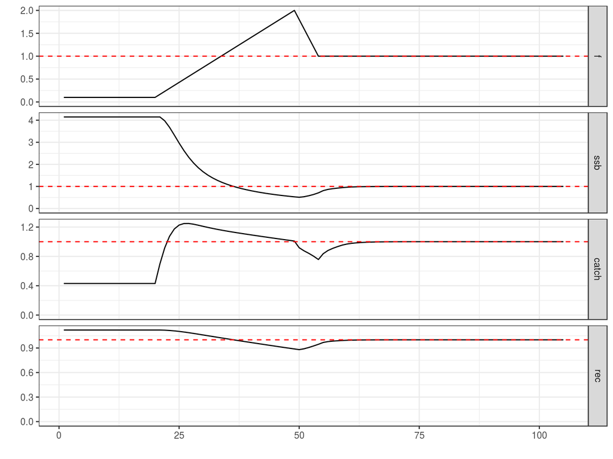

**Figure 4** Time series relative to MSY benchmarks.

# Length Based Methods

Based on Beverton and Holt $L_{F} = \frac{L\infty +\frac{F+M}{K}L_c}{1+\frac{F+M}{K}}$

- $L_{current}/L_{F=M}$
- $M/(Z_{current}-M)$
- $F_{0.1}/(Z_{current}-M)$
- $LBSPR$ Length-based spawning potential ratio (Hordyk et al. 2015)
- $Lime$ (Rudd and Thorson, 2018) mixed effects non-equilibrium

## MLZ

[MLZ](https://cran.r-project.org/web/packages/MLZ/index.html) is a package that facilitates data preparation and estimation of mortality with statistical diagnostics using the mean length-based mortality estimator and several extensions.

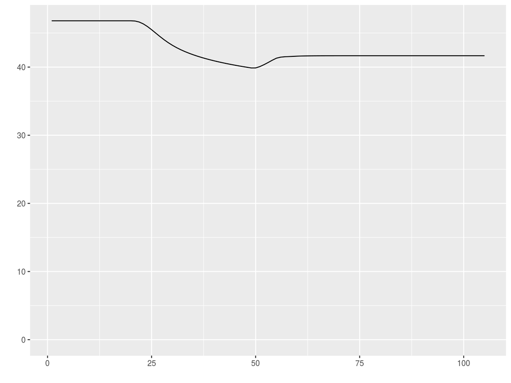

**Figure 5** Mean length of catch turbot.

```
         iter   Estimate   Std. Error
Z[1]        1  1.3111029 2.850011e-02
Z[2]        1  0.9298101 2.790601e-02
yearZ[1]    1 52.1806853 4.389703e-01
sigma       1  5.7929436 4.093996e-14
```

## LB-SPR

[LBSPR](https://cran.r-project.org/web/packages/LBSPR/vignettes/LBSPR.html) is a R package for simulation and estimation using life-history ratios and length composition data

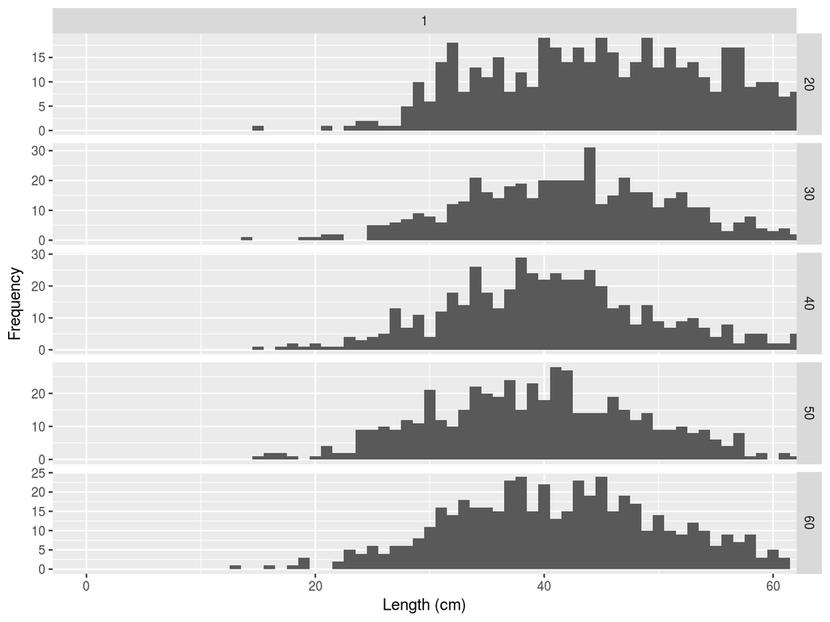

**Figure 6** Observation error model for turbot.

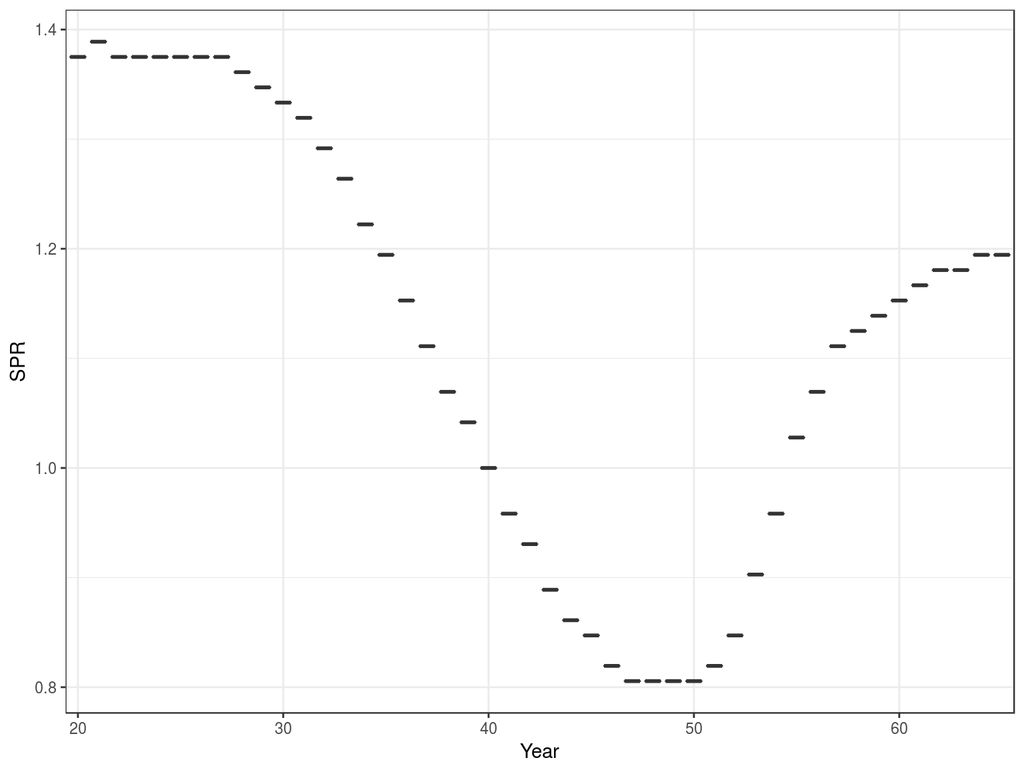

**Figure 7** Estimates of SPR for turbot.

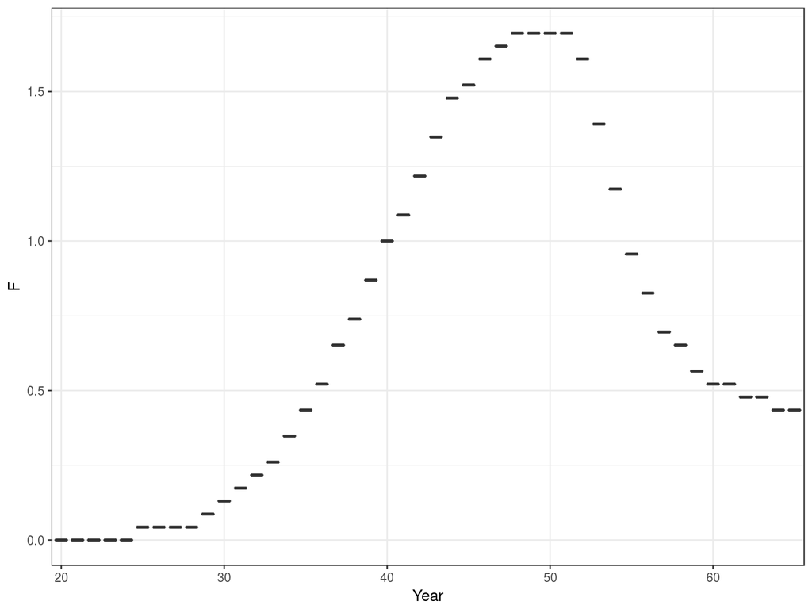

**Figure 8** Estimates of $F/M$ for turbot.

# More information

- You can submit bug reports, questions or suggestions on this tutorial at https://github.com/flr/doc/issues.
- Or send a pull request to https://github.com/flr/doc/
- For more information on the FLR Project for Quantitative Fisheries Science in R, visit the FLR webpage, http://flr-project.org.

## Software Versions

- R version 3.5.1 (2018-07-02)
- FLCore: 2.6.10
- FLasher: 0.5.0
- **Compiled**: Thu Dec 6 13:49:19 2018

## License

This document is licensed under the [Creative Commons Attribution-ShareAlike 4.0 International](https://creativecommons.org/licenses/by-sa/4.0) license.

## Author information

**Laurence KELL**. laurie@seaplusplus.co.uk

## Acknowledgements

This vignette and the methods documented in it were developed under the MyDas project funded by the Irish exchequer and EMFF 2014-2020. The overall aim of MyDas is to develop and test a range of assessment models and methods to establish Maximum Sustainable Yield (MSY) reference points (or proxy MSY reference points) across the spectrum of data-limited stocks.